# Computational Statistics

Jonas Wortmann

2023-07-06

# Projekt Corona

Wir wollen den Verlauf einer Infektion innerhalb einer homogenen Population untersuchen. Hierzu verwenden wir das SIR Modell als ‘stochastic individual contact model (ICM)’, d.h. die Simulation verläuft auf individueller Ebene mit stochastischen Übergängen von SIR. Untersuchen Sie eine Population von N = 5000 Personen, von denen zum Zeitpunkt t = 0, I = 10 Individuen bereits infiziert sind. Zu Beginn soll es noch keine immunisierten Personen geben (R0 = 0). Wir gehen davon aus, dass es bei einer Begegnung von einer infizierbaren zu einer bereits infizierten Person mit einer Wahrscheinlichkeit von inf.prob = 10% zu einer Ansteckung kommt. Ferner gehen Sie von einer Begegnungsrate einer infizierten Person zu infizierbaren Personen von act.rate = 10 pro Tag aus. Die Zeit von einer Infektion bis zu einer Immunisierung betrage 14 Tage. Ferner gehen Sie bitte von einer Geburt in 100 Tagen so wie einer Todesrate von jeweils einer von 90 Personen bei gesunden und Immunen, bzw. von zwei von 90 Personen unter den infizierten aus.

### Simulation des Verlaufs der Verbreitung in 50 Tagen

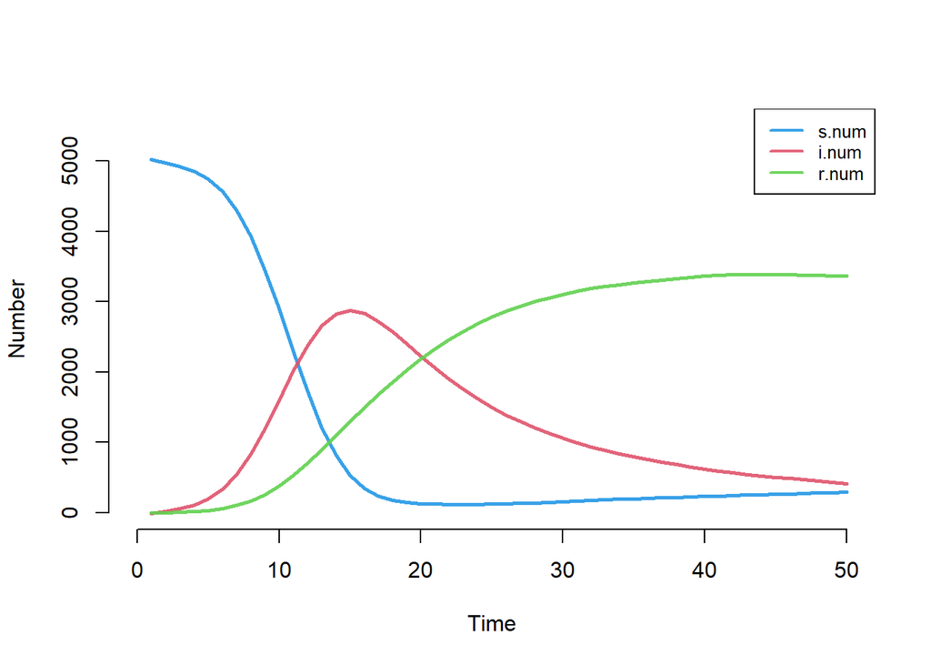

```r
library(EpiModel)
N <- 5000
I_0 <- 10 # bereits infizierte Personen zum Zeitpunkt t=0
R_0 <- 0 # Anzahl immunisierte Personen zum Zeitpunkt t=0
inf.prob <- 0.1 # Wahrscheinlichkeit einer Infektion
act.rate <- 10 # Begegnungsrate einer infizierten Person zu infizierbaren Person
rec.rate <- 1/14 # recovery rate
birth_rate <- 1/100
I.death_rate <- 2/90 # Todesrate einer infizierten Person
S.death_rate <- 1/90 # Todesrate einer gesunden Person
n <- 50 # Anzahl Tage der Simulation

#  stochastic individual contact model (SIR)
param <- param.icm(inf.prob=inf.prob,
          act.rate=act.rate,
          rec.rate=rec.rate,
          di.rate=I.death_rate,
          ds.rate=S.death_rate,
          dr.rate=S.death_rate,
          a.rate=birth_rate,
          )

init <- init.icm(s.num=(N-I_0), # Anzahl gesunde Personen zum Zeitpunkt t=0
         i.num=I_0,
         r.num=R_0,

         )

control <- control.icm(type="SIR", nsteps=n)

mod_a <- icm(param, init, control)

plot(mod_a)
```

### Hygienevorschriften

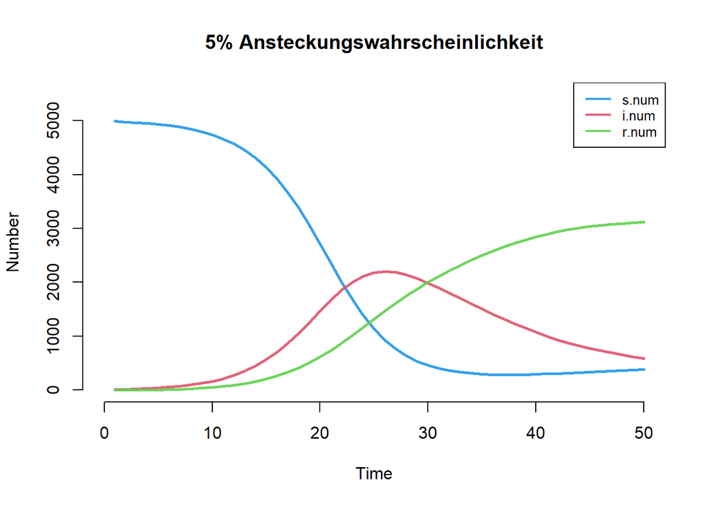

```r
inf.prob_5 <- 0.05
param <- param.icm(inf.prob=inf.prob_5,
          act.rate=act.rate,
          rec.rate=rec.rate,
          di.rate=I.death_rate,
          ds.rate=S.death_rate,
          dr.rate=S.death_rate,
          a.rate=birth_rate
          )

mod_b <- icm(param, init, control)

plot(mod_b, main="5% Ansteckungswahrscheinlichkeit")
```

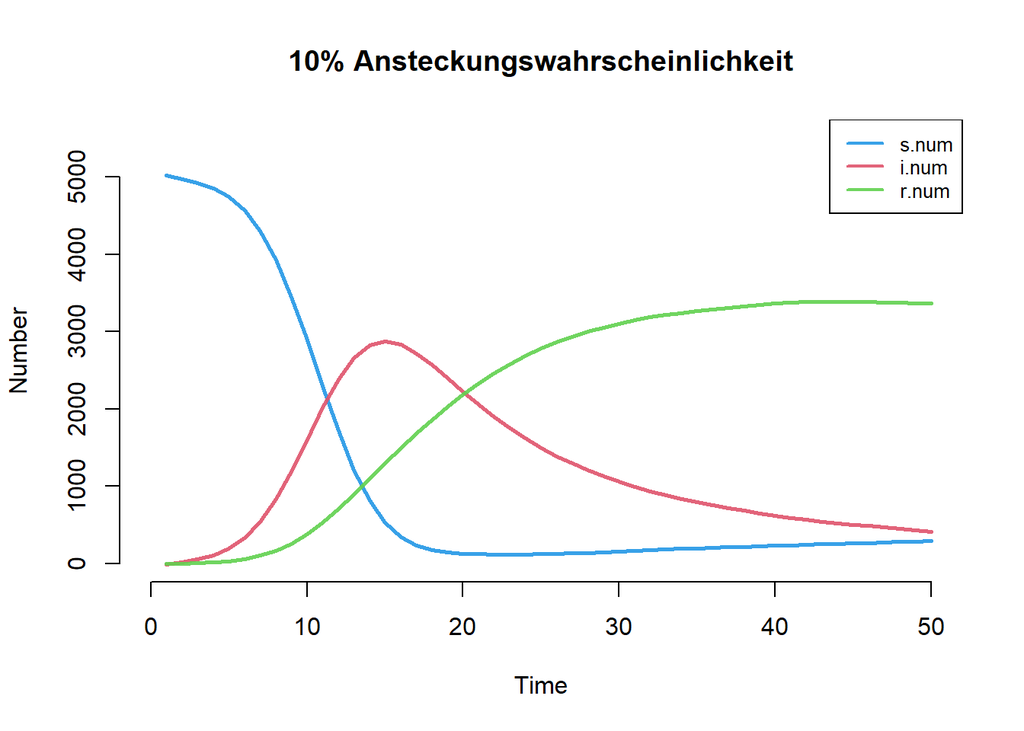

```r
plot(mod_a, main="10% Ansteckungswahrscheinlichkeit")
```

Durch die Maßnahmen flacht die Ansteckungskurve ab und geht langsamer auf den Hochpunkt zu.

### Kontakteinschränkungen

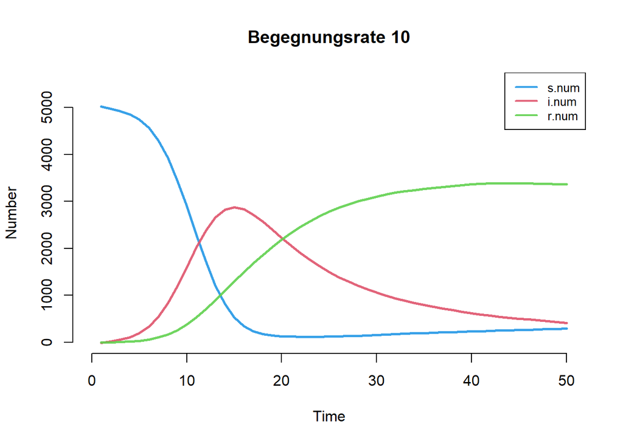

```r
act.rate_5 <- 5
act.rate_2 <- 2

param <- param.icm(inf.prob=inf.prob,
          act.rate=act.rate_5,
          rec.rate=rec.rate,
          di.rate=I.death_rate,
          ds.rate=S.death_rate,
          dr.rate=S.death_rate,
          a.rate=birth_rate
          )

mod_c <- icm(param, init, control)

param <- param.icm(inf.prob=inf.prob,
          act.rate=act.rate_2,
          rec.rate=rec.rate,
          di.rate=I.death_rate,
          ds.rate=S.death_rate,
          dr.rate=S.death_rate,
          a.rate=birth_rate
          )

mod_d <- icm(param, init, control)



plot(mod_a, main="Begegnungsrate 10")
```

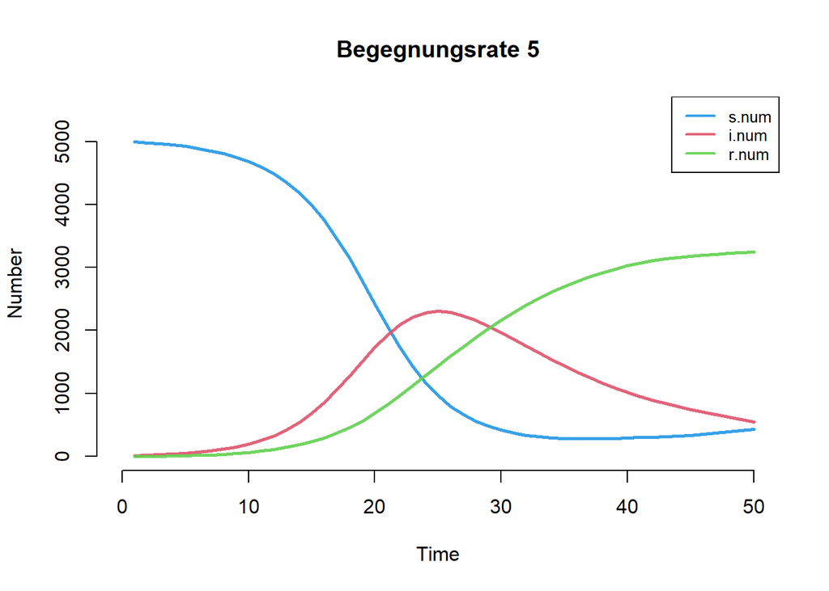

```r
plot(mod_c, main="Begegnungsrate 5")
```

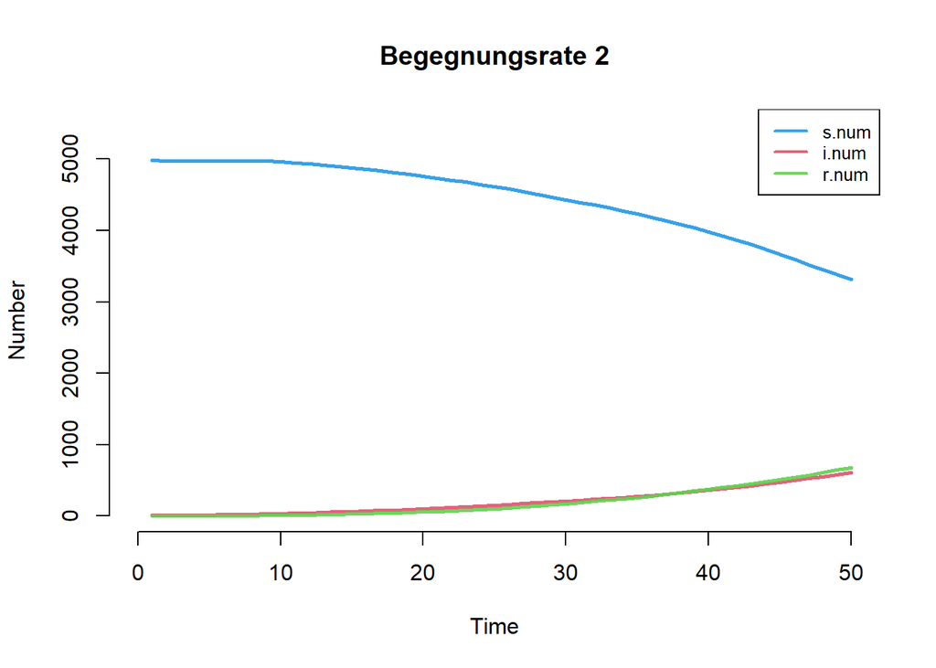

```r
plot(mod_d, main="Begegnungsrate 2")
```

Analog zu b) flacht die Ansteckungskurve durch eine geringere Begegnungsrate ab. Da sich weniger Infizierte mit nicht-Infizierten begegnen ist die Wahrscheinlichkeit sich anzustecken geringer.

### Kontakteinschränkungen + Hygienevorschriften

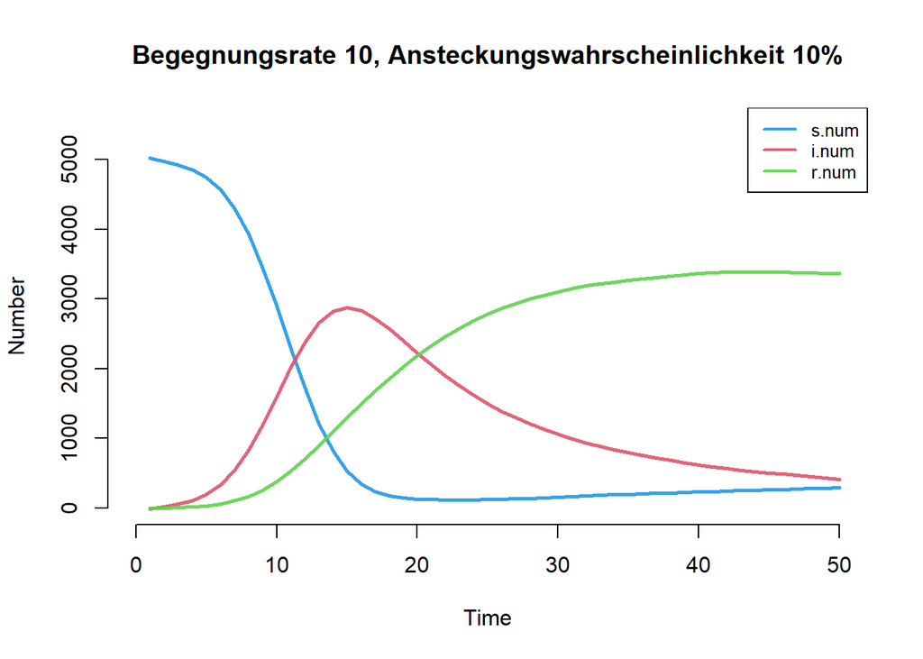

```r
param <- param.icm(inf.prob=inf.prob_5,
          act.rate=act.rate_5,
          rec.rate=rec.rate,
          di.rate=I.death_rate,
          ds.rate=S.death_rate,
          dr.rate=S.death_rate,
          a.rate=birth_rate
          )
control_n_100 <- control.icm(type="SIR", nsteps=100) # um den Verlauf besser vergleichen zu können unter den zwei neuen Modellen wird jetzt auf 100 Tage simuliert
mod_e <- icm(param, init, control_n_100)

param <- param.icm(inf.prob=inf.prob_5,
          act.rate=act.rate_2,
          rec.rate=rec.rate,
          di.rate=I.death_rate,
          ds.rate=S.death_rate,
          dr.rate=S.death_rate,
          a.rate=birth_rate
          )
mod_f <- icm(param, init, control_n_100)

plot(mod_a, main="Begegnungsrate 10, Ansteckungswahrscheinlichkeit 10%")
```

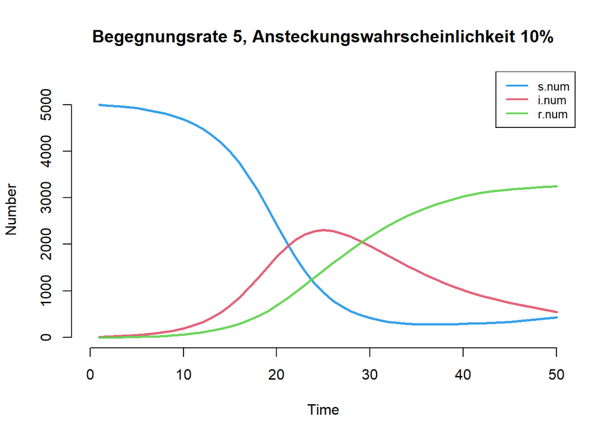

```r
plot(mod_c, main="Begegnungsrate 5, Ansteckungswahrscheinlichkeit 10%")
```

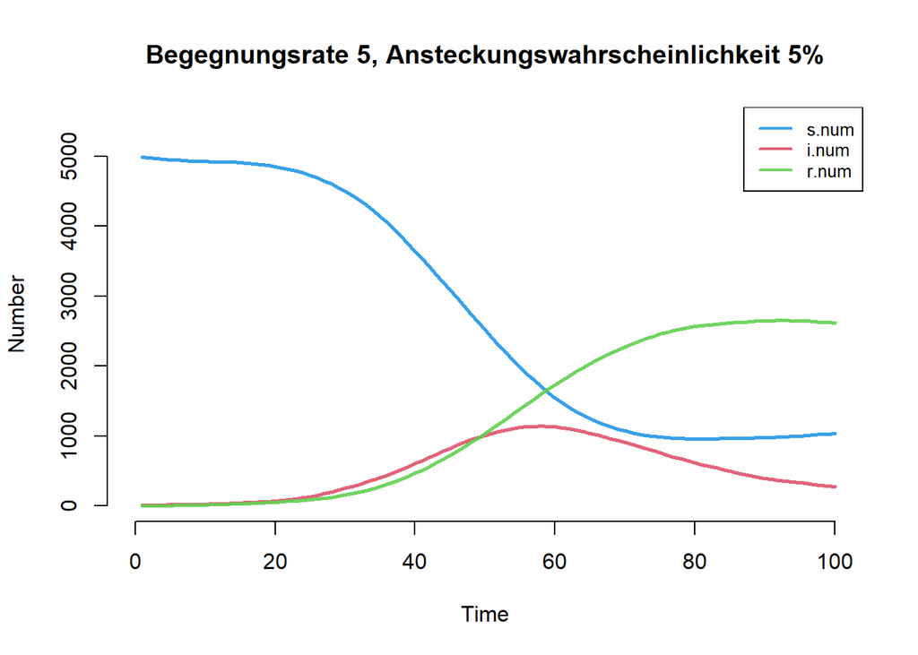

```r
plot(mod_e, main="Begegnungsrate 5, Ansteckungswahrscheinlichkeit 5%")
```

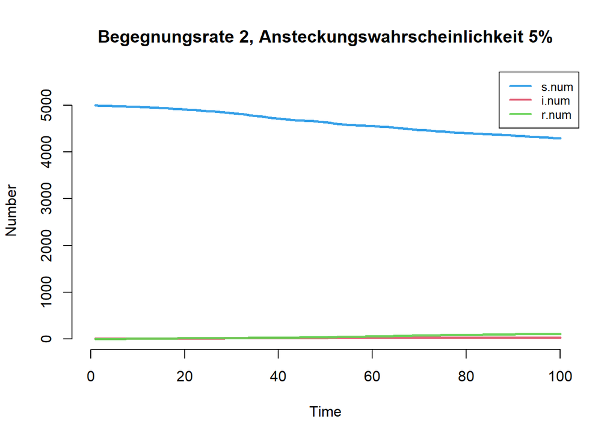

```r
plot(mod_f, main="Begegnungsrate 2, Ansteckungswahrscheinlichkeit 5%")
```

Weiterhin gilt, je geringer die Ansteckungswahrscheinlichkeit und Begegnungsrate desto langsamer ist der Infektionsverlauf. Interessant ist, dass bei einer Ansteckungswahrscheinlichkeit von 5% und Begegnungsrate von 2 die Kurve so abflacht, dass man die Steigung der Infektionszahl selbst nach 100 Tagen nicht wahrnimmt.

### Variation der Zeitpunkte tH und tK

```r
# source("custom_infection_fun.R")
# param_0.5_10d <- param.icm(inf.prob=inf.prob,
#           act.rate=act.rate,
#           rec.rate=rec.rate,
#           di.rate=I.death_rate,
#           ds.rate=S.death_rate,
#           dr.rate=S.death_rate,
#           a.rate=birth_rate,
#           inf.prob.new = 0.02, # neue Ansteckungswahrscheinlichkeit
#           inf.prob.new.start=5 # nach 5 Tagen
#           )
#
# param_0.5_20d <- param.icm(inf.prob=inf.prob,
#           act.rate=act.rate,
#           rec.rate=rec.rate,
#           di.rate=I.death_rate,
#           ds.rate=S.death_rate,
#           dr.rate=S.death_rate,
#           a.rate=birth_rate,
#           inf.prob.new = 0.02, # neue Ansteckungswahrscheinlichkeit
#           inf.prob.new.start=20 # nach 20 Tagen
#           )
#
# param_act_rate_5d <- param.icm(inf.prob=inf.prob,
#           act.rate=act.rate,
#           rec.rate=rec.rate,
#           di.rate=I.death_rate,
#           ds.rate=S.death_rate,
#           dr.rate=S.death_rate,
#           a.rate=birth_rate,
#           act.rate.new = 5, # Kontaktbeschränkungen
#           act.rate.new.start=5 # nach 5 Tagen
#           )
#
# param_act_rate_5d_to_30d <- param.icm(inf.prob=inf.prob,
#           act.rate=act.rate,
#           rec.rate=rec.rate,
#           di.rate=I.death_rate,
#           ds.rate=S.death_rate,
#           dr.rate=S.death_rate,
#           a.rate=birth_rate,
#           act.rate.new = 5, # Kontaktbeschränkungen
#           act.rate.new.start=5, # nach 5 Tagen
#           act.rate.new.end=30 # Ende nach 30 Tagen
#           )
#
#
#
# control <- control.icm(type="SIR", nsteps=n, infection.FUN = infection.icm_custom)
#
# mod_a_maßnahmen_0.5_10d <- icm(param_0.5_10d, init, control)
# mod_a_maßnahmen_0.5_20d <- icm(param_0.5_20d, init, control)
# mod_a_maßnahmen_act_rate_5d <- icm(param_act_rate_5d, init, control)
# mod_a_maßnahmen_act_rate_5d_to_30d <- icm(param_act_rate_5d_to_30d, init, control)
#
# plot(mod_a, main="keine Maßnahmen")
# plot(mod_a_maßnahmen_0.5_10d, main="Hygienevorschriften nach 5 Tagen")
# plot(mod_a_maßnahmen_0.5_20d, main="Hygienevorschriftenmen nach 20 Tagen")
# plot(mod_a_maßnahmen_act_rate_5d, main="Kontaktbeschränkungen nach 5 Tagen")
# plot(mod_a_maßnahmen_act_rate_5d_to_30d, main="Kontaktbeschränkungen von Tag 5 bis Tag 30")
```

Beim Ausführen der Funktion erscheint der Fehler :

Error in if (!is.null(dat$param$inf.prob.new) && at >= dat$param$inf.prob.new.start && : missing value where TRUE/FALSE needed

Deshalb habe ich den Code auskommentiert.

### Alternative Modelle

#### SIS-Modell

Wenn sich Personen nach einer gewissen Zeit erneut anstecken können, bedeutet das, dass der Zustand “Recovered” nach einer bestimmten Zeit *t* in den Zustand “Susceptible” übergeht. Das SIS (Susceptible-Infectious-Susceptible)-Modell wäre in diesem Fall besser, da es Langzeitimmunität ausschließt.

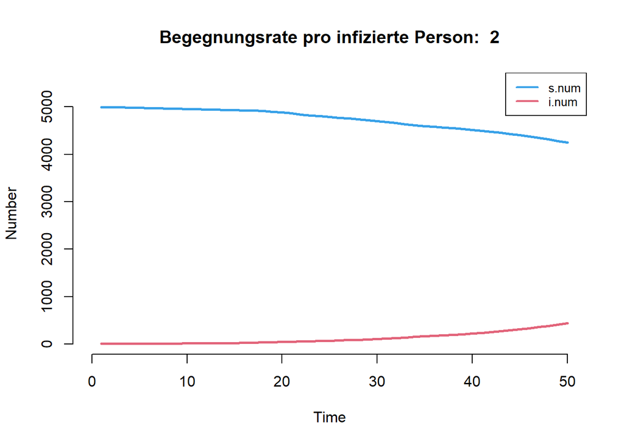

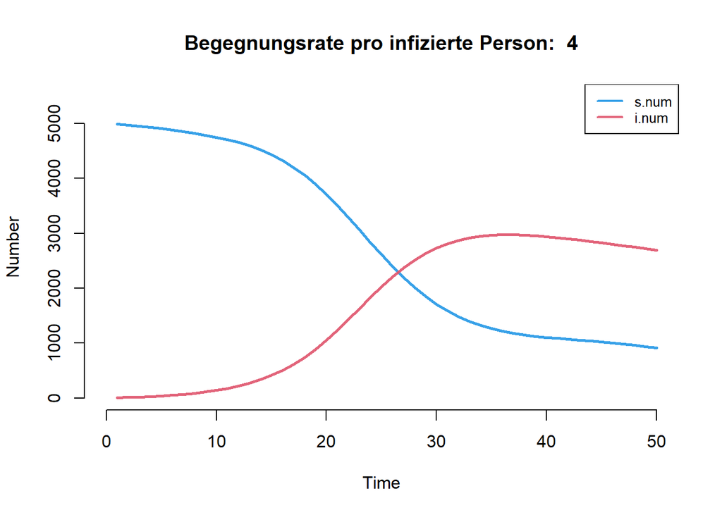

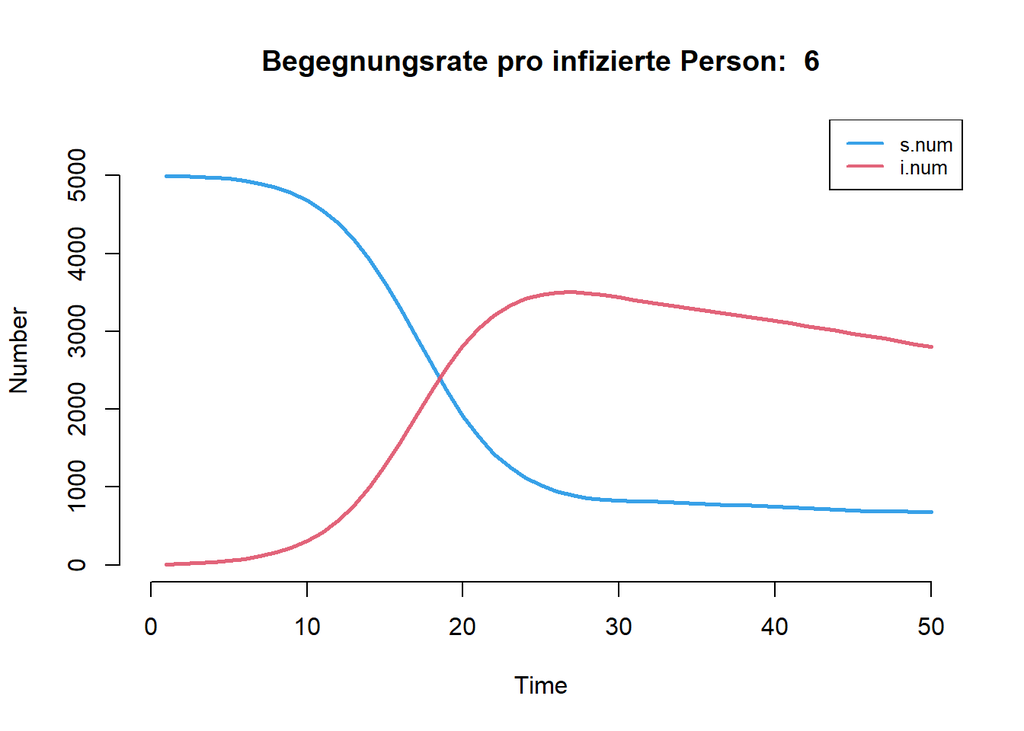

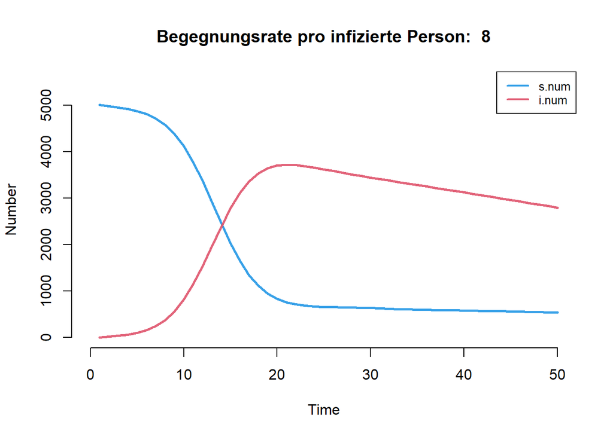

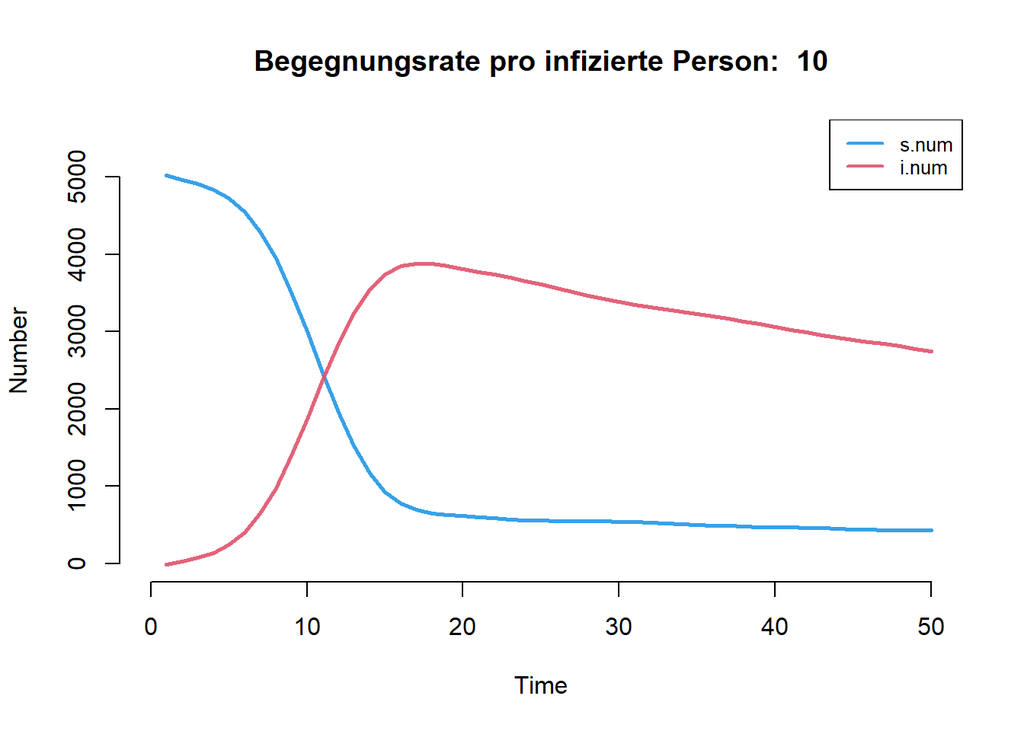

```r
n <- 50
control <- control.icm(type="SIS", nsteps=n)

for (i in seq(2,10,2)){ #vary act rate
  param <- param.icm(inf.prob=inf.prob,
          act.rate=i,
          rec.rate=rec.rate,
          di.rate=I.death_rate,
          ds.rate=S.death_rate,
          dr.rate=S.death_rate,
          a.rate=birth_rate
          )

  mod_sis <- icm(param, init, control)
  plot(mod_sis, main=paste("Begegnungsrate pro infizierte Person: ", as.character(i)))
}
```

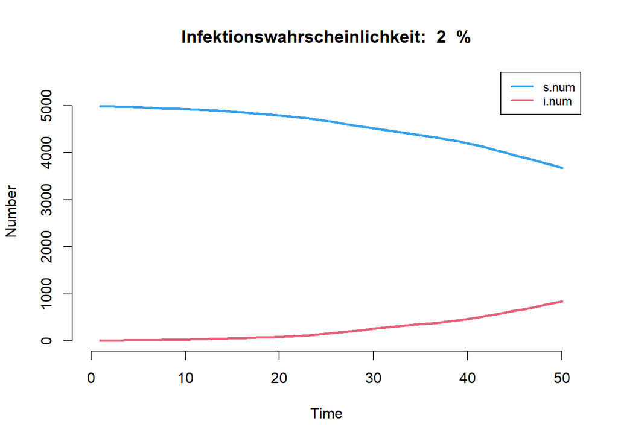

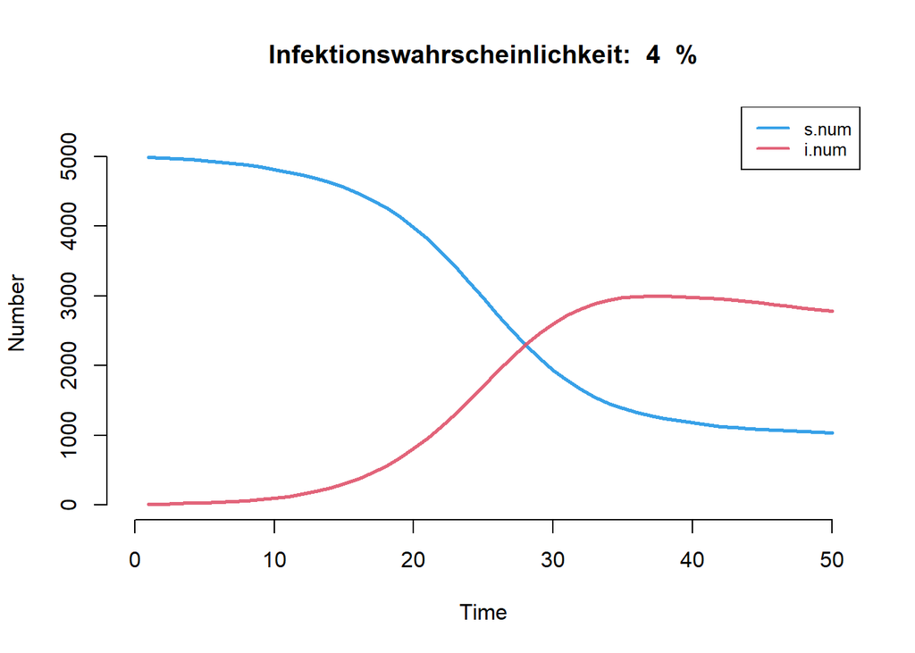

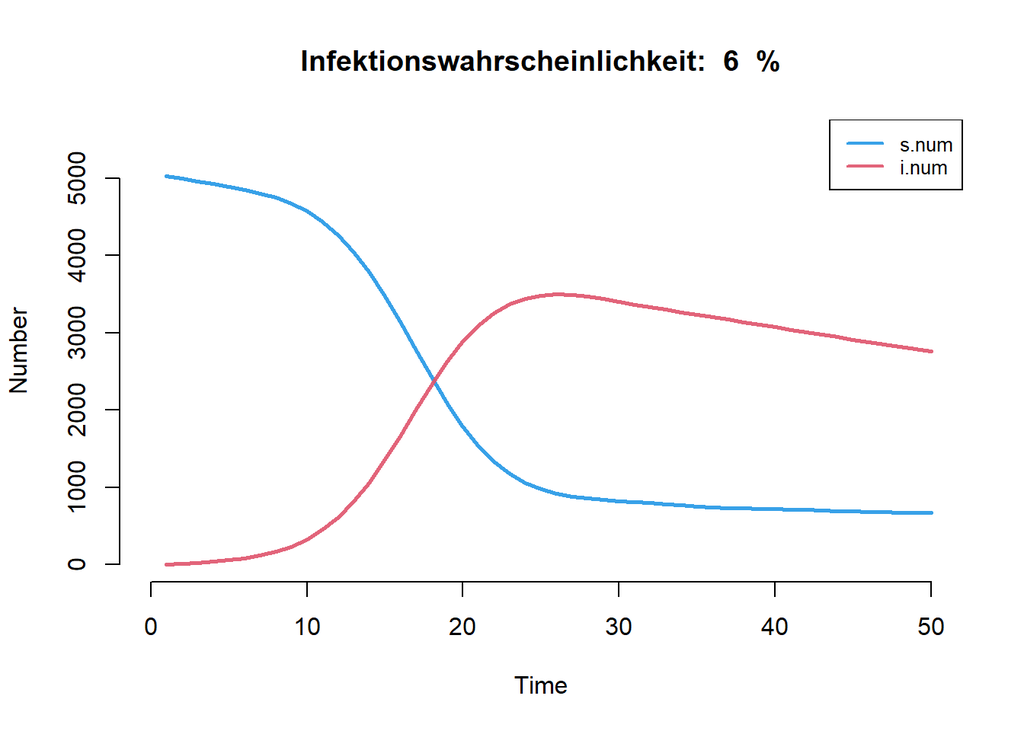

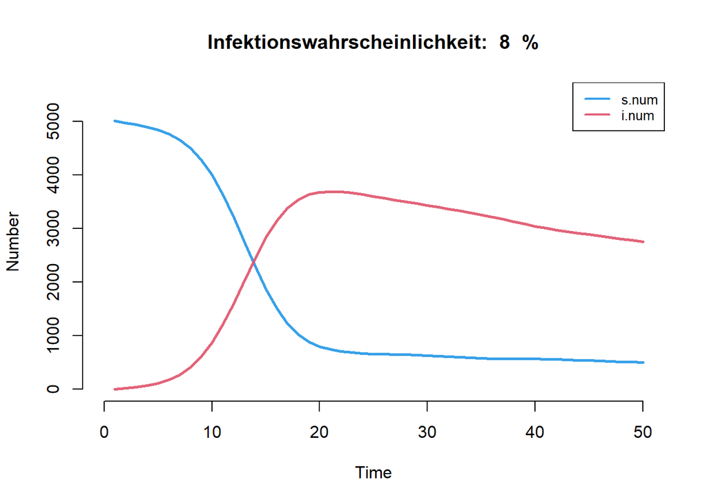

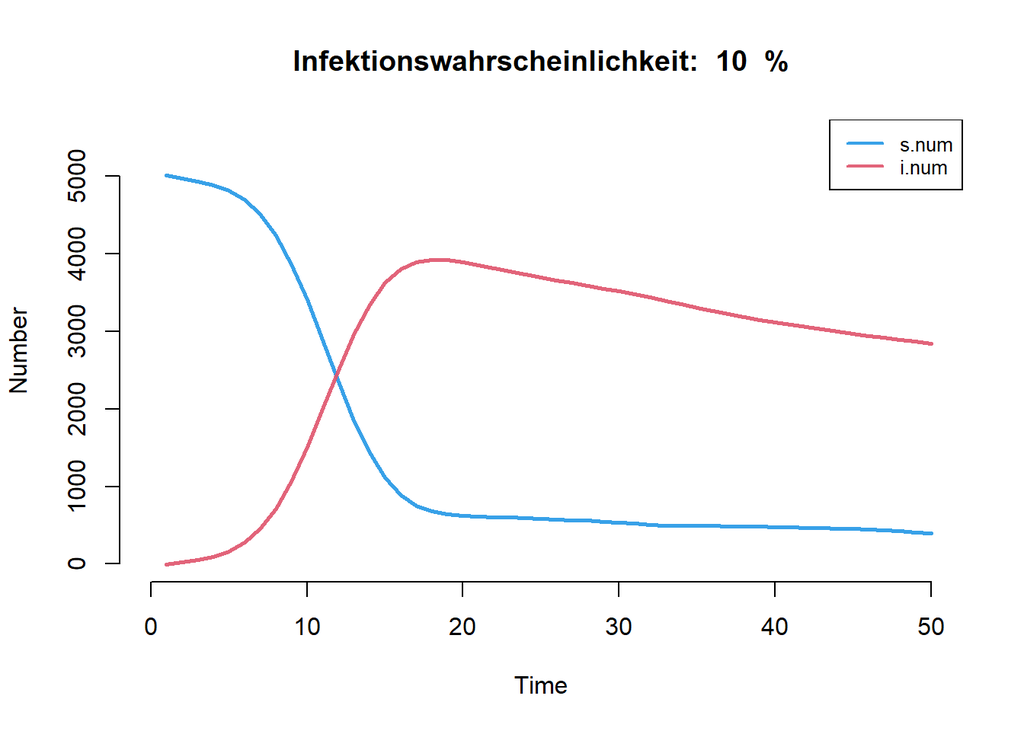

```r
for (i in seq(0.02, 0.1, 0.02)){ #vary Infection probability
  param <- param.icm(inf.prob=i,
          act.rate=act.rate,
          rec.rate=rec.rate,
          di.rate=I.death_rate,
          ds.rate=S.death_rate,
          dr.rate=S.death_rate,
          a.rate=birth_rate
          )

  mod_sis <- icm(param, init, control)
  plot(mod_sis, main=paste("Infektionswahrscheinlichkeit: ", as.character(i*100), " %"))
}
```

#### Virusvarianten

Im Verlauf der Pandemie gab es zahlreiche verschiedene Virus-Varianten. Was bedeuten diese Varianten für die Modellierung? Wie könnte man ein Modell mit verschiedenen Varianten umsetzen und welche Probleme können sich dabei ergeben?

Die Varianten unterscheiden sich u. a. an der Ansteckungswahrscheinlichkeit, die Todesrate und Recovery Rate. Um die Verbreitung von verschiedenen Varianten umzusetzen, müsste man pro Virus-Variante ein eigenes Modell mit den entsprechenenden Parametern aufsetzen und sie parallel simulieren. Da die Simulationen im R-Paket EpiModel isoliert voneinander ausgeführt werden, können bereits Infizierte einer Variante theoretisch mehrmals infiziert sein, d. h. die Zustände verschiedener Virusvarianten könnten überlappen.

#### Impfungen

Wie kann man die Impfungen mit einbeziehen? Auf welche Parameter haben Impfungen Einfluss? Sind diese Einflusse konstant?

Impfungen haben Einfluss auf die Ansteckungswahrscheinlichkeit und die Schwere der Erkrankung, d. h. sie haben auch Einfluss auf die Todesrate und die Länge der Erkrankung. Da Impfungen nicht konstant vor einer Ansteckung oder schweren Verlauf schützen, müsste dafür ein geeignete Modellierung ausgewählt werden, die pro geimpfte Person die Tage nach Impfung berücksichtigt, d. h. dass die genannten Parameter (Ansteckungswahrscheinlichkeit & Länge der Erkrankung) sich im Laufe der Simulation pro Person ändern.

# Cross Validation

### Lineare Regression

```r
load("data/Donald.RData")

Donald_1$Minderheit <- factor(Donald_1$Minderheit)
Donald_1$Geschlecht <- factor(Donald_1$Geschlecht, labels=c("w", "m"))

model <- lm(Trump ~ Alter+Geschlecht+Minderheit+Fremdenfeindlich+IQ, data=Donald_1)
summary(model)
```

```
##
## Call:
## lm(formula = Trump ~ Alter + Geschlecht + Minderheit + Fremdenfeindlich +
##     IQ, data = Donald_1)
##
## Residuals:
##      Min       1Q   Median       3Q      Max
## -15.6835  -4.5286  -0.0023   4.1231  13.0974
##
## Coefficients:
##                  Estimate Std. Error t value Pr(>|t|)
## (Intercept)      29.73834    3.60973   8.238 9.73e-14 ***
## Alter             0.18153    0.03049   5.954 1.91e-08 ***
## Geschlechtm       5.75572    0.99977   5.757 4.97e-08 ***
## Minderheit1      -6.57586    1.82843  -3.596 0.000443 ***
## Fremdenfeindlich  9.34984    0.16325  57.272  < 2e-16 ***
## IQ               -0.40135    0.03016 -13.309  < 2e-16 ***
## ---
## Signif. codes:  0 '***' 0.001 '**' 0.01 '*' 0.05 '.' 0.1 ' ' 1
##
## Residual standard error: 6.065 on 144 degrees of freedom
## Multiple R-squared:  0.9713, Adjusted R-squared:  0.9703
## F-statistic: 973.6 on 5 and 144 DF,  p-value: < 2.2e-16
```

Je älter desto höher ist die Zustimmung für Trump. Männliche Wahlberechtigte stimmen eher für Trump. Personen, die keiner Minderheit angehören stimmen eher für Trump als Personen, die einer Minderheit angehören. Fremdenfeindliche Wähler stimmen eher für Trump als nicht-fremdenfeindliche. Je niedriger der IQ, desto höher ist die Zustimmung für Trump.

### Split in Test- und Trainingsdaten und Vergleich der Verteilungen der Variablen

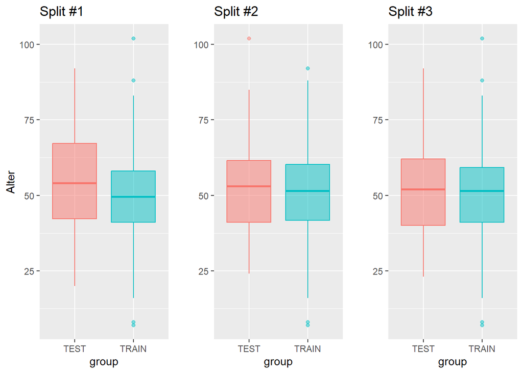

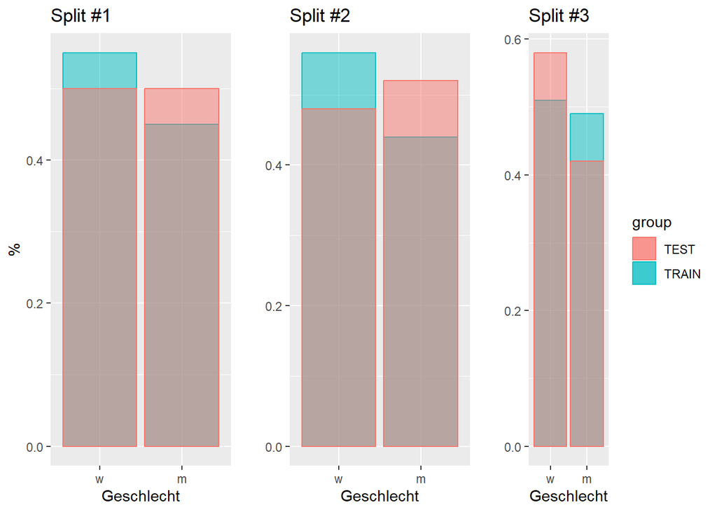

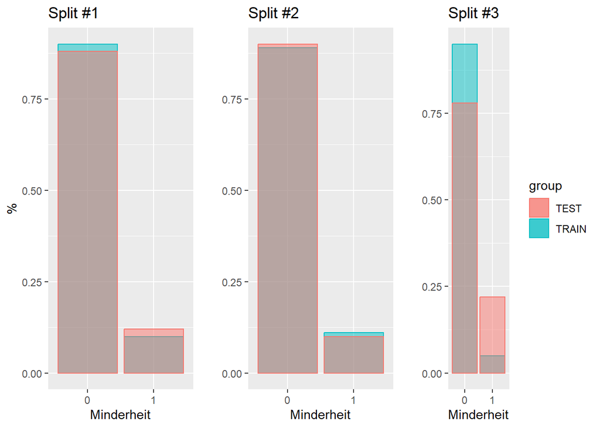

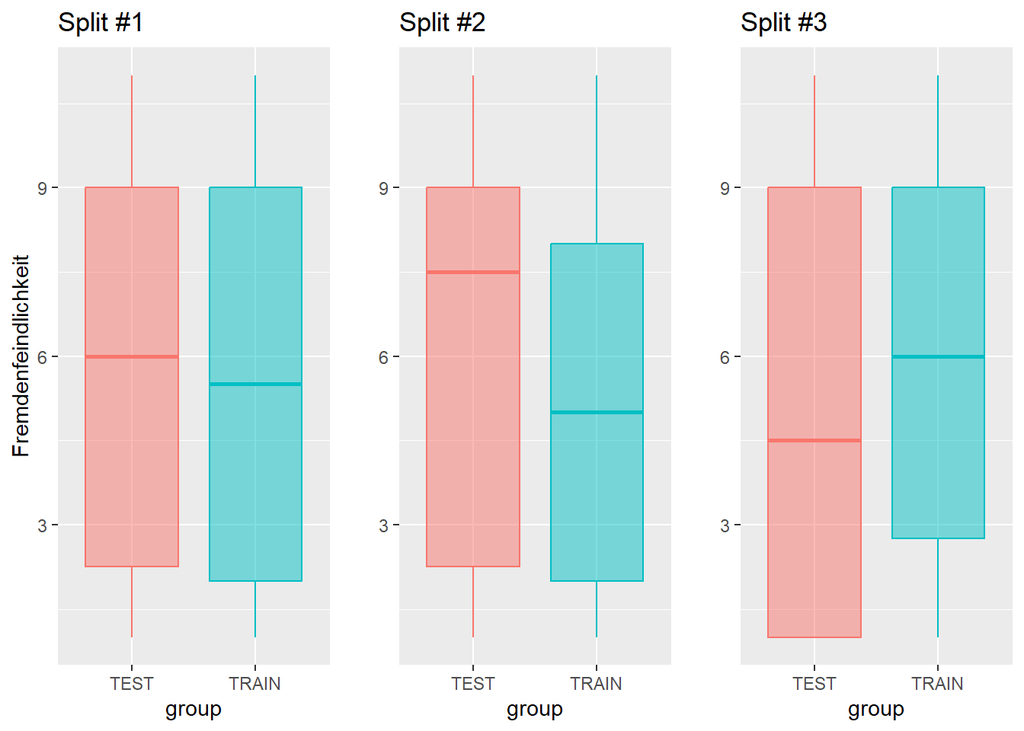

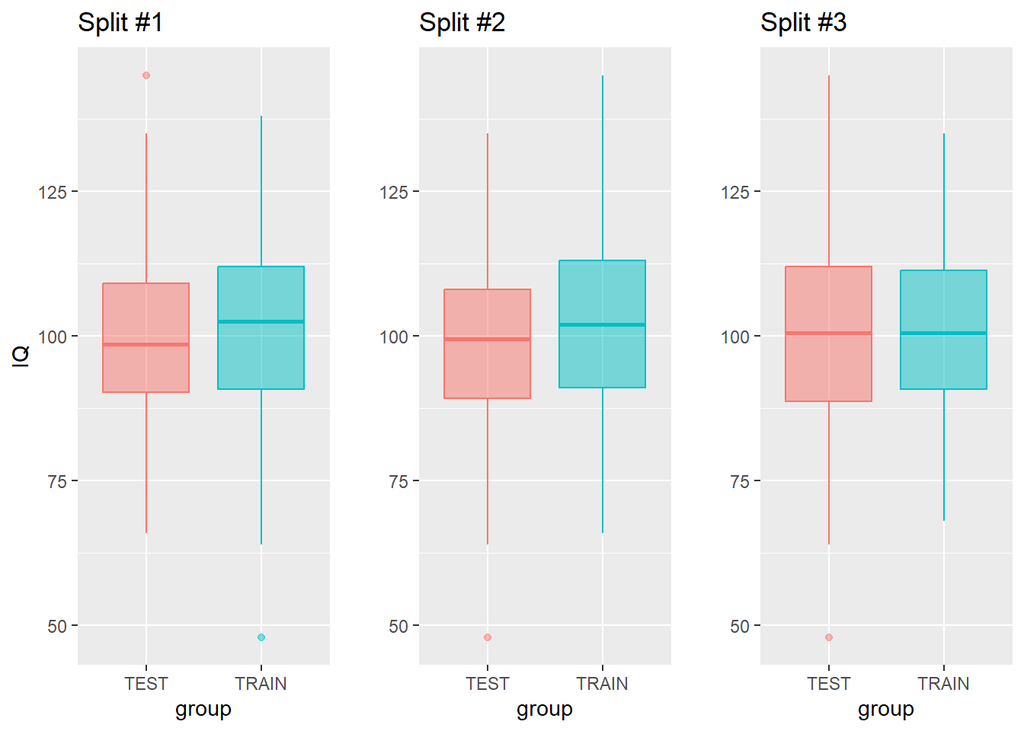

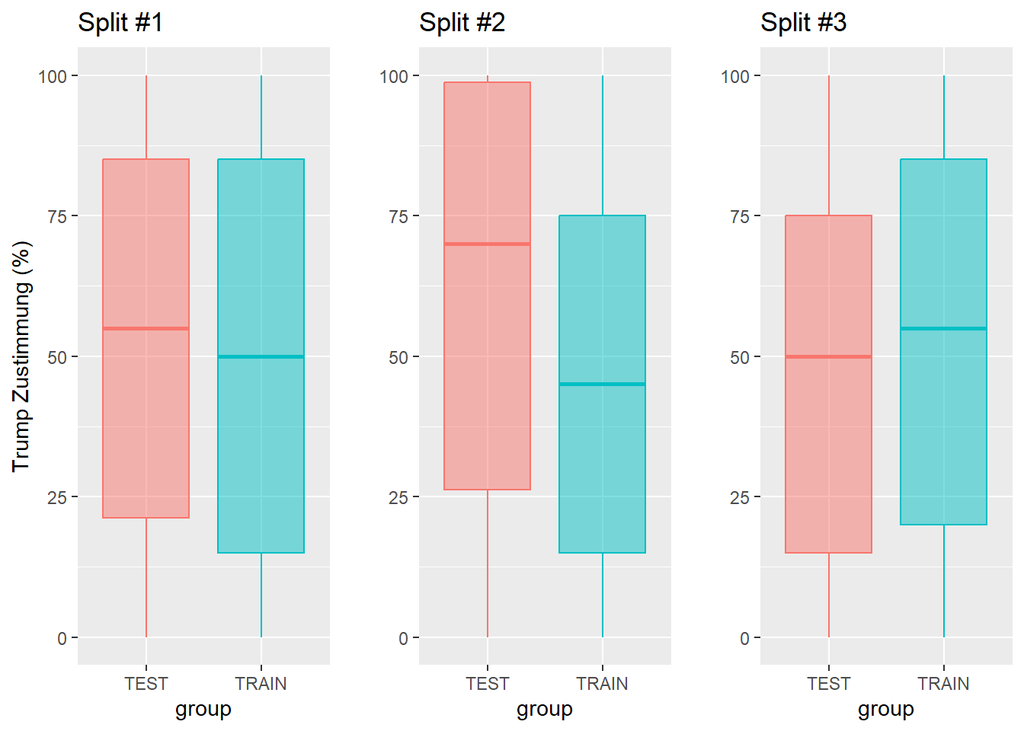

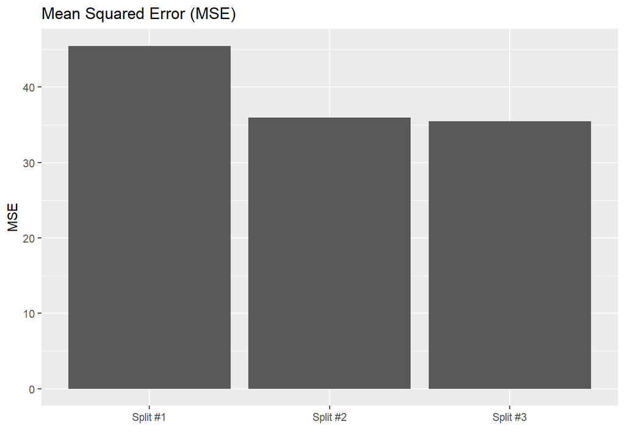

### Leave-One-Out Cross Validation

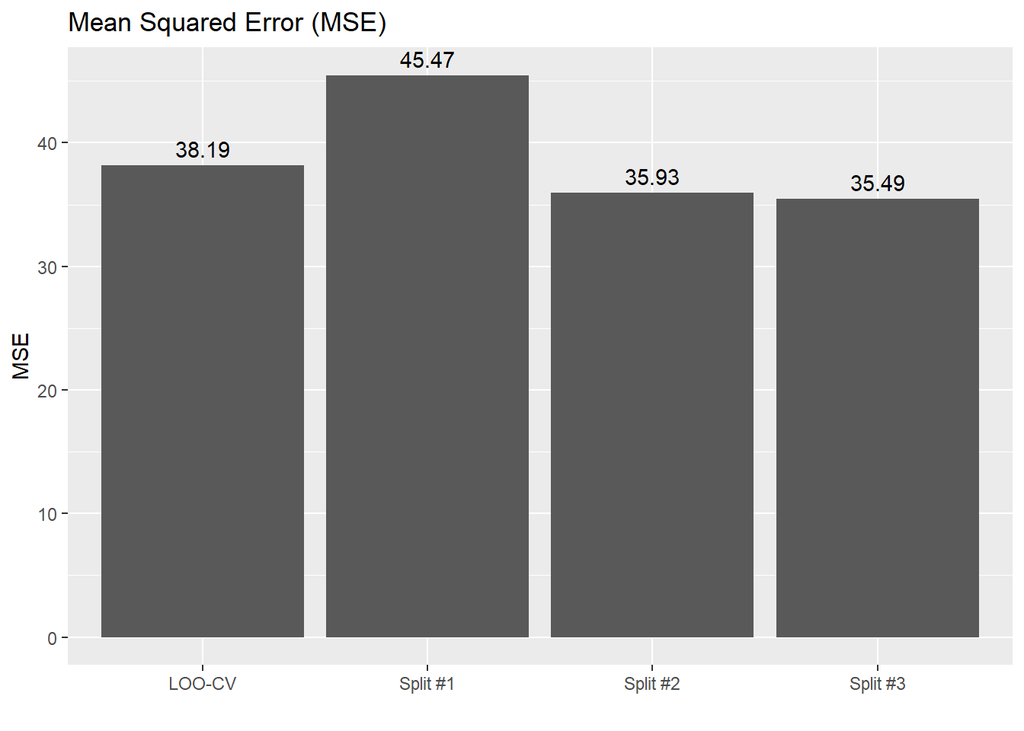

```r
ses <- c()
for(i in 1:nrow(Donald_1)){
  data <- Donald_1[-i,]
  model <- lm(Trump ~ Alter+Geschlecht+Minderheit+Fremdenfeindlich+IQ, data=data)
  prediction <- predict(model, Donald_1[i,])
  squared_error <- (Donald_1[i,]$Trump - prediction)**2
  ses <- c(ses, squared_error)
}
mse_loo <- mean(ses)
mses <- c(mses,mse_loo)
mses <- round(mses, 2)
ggplot(data.frame(MSE=mses), aes(x = c("Split #1", "Split #2", "Split #3", "LOO-CV"), y = MSE)) +
  geom_bar(stat = "identity") +
  xlab("") +
  ylab("MSE") +
  ggtitle("Mean Squared Error (MSE)") +
  geom_text(aes(label=MSE), vjust=-0.5)
```

Der MSE von Split #2 und #3 ist geringer als der von der LOO-CV. Der MSE von allen CV-Splits hängt stark von den Samples im Training- und Testdatensatz ab. Ist der Split günstig, d. h. lässt sich der Testdatensatz durch den Trainingsdatensatz gut vorhersagen, führt das zu einem geringen MSE. Aber nur weil der Testdatensatz des Splits gut vorhersagbar ist, heißt das nicht, dass es auf weitere ungesehene Daten zutrifft. Die LOO-Methode passt das Modell an allen Daten an, darum ist das Ergebnis konstant.

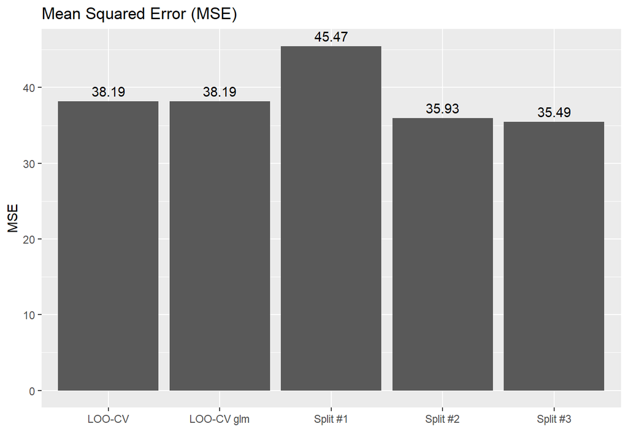

```r
# Leave one Out mit der glm Funktion
library(boot)
linear.reg_model <- glm(Trump ~ Alter+Geschlecht+Minderheit+Fremdenfeindlich+IQ, data=Donald_1)
cv_glm <- cv.glm(Donald_1, linear.reg_model)
mse_loo_glm <- round(cv_glm$delta[1], 2)
mses <- c(mses,mse_loo_glm)
ggplot(data.frame(MSE=mses), aes(x = c("Split #1", "Split #2", "Split #3", "LOO-CV", "LOO-CV glm"), y = MSE)) +
  geom_bar(stat = "identity") +
  xlab("") +
  ylab("MSE") +
  ggtitle("Mean Squared Error (MSE)") +
  geom_text(aes(label=MSE), vjust=-0.5)
```

Das Ergebnis mit cv.glm ist mit der Loop-Durchführung identisch.

### k-fache Cross Validation

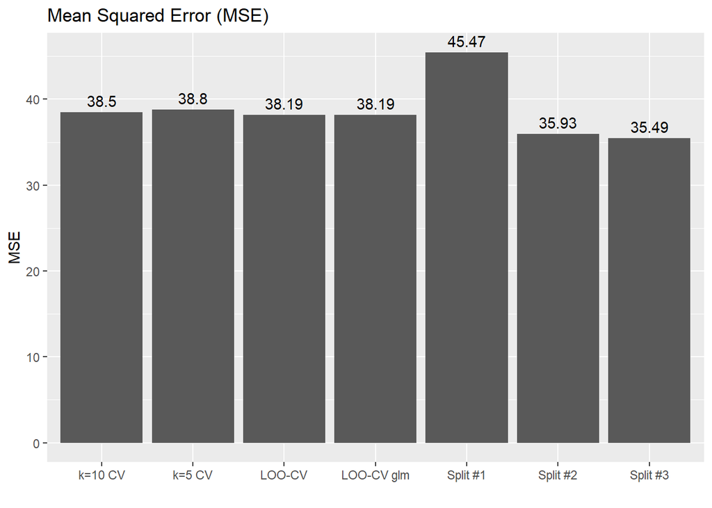

```r
for(K in c(5,10)){
  errors <- c()
  for(i in 1:10){
    cv_glm <- cv.glm(Donald_1, linear.reg_model, K=K)
    errors <- c(errors,round(cv_glm$delta[1]))
  }
  mse <- mean(errors)
  mses <- c(mses, mse)
}
ggplot(data.frame(MSE=mses), aes(x = c("Split #1", "Split #2", "Split #3", "LOO-CV", "LOO-CV glm",
                                       "k=5 CV", "k=10 CV"), y = MSE)) +
  geom_bar(stat = "identity") +
  xlab("") +
  ylab("MSE") +
  ggtitle("Mean Squared Error (MSE)") +
  geom_text(aes(label=MSE), vjust=-0.5)
```

Die MSEs der k-fachen Cross Validierung zeigt mit k=5 und k=10 keine großen Differenzen auf. Auch zur LOO-CV ist kein großer Unterschied zu sehen. Mit der k-fachen Cross Validierung lässt sich zwar Rechenleistung sparen, bei dieser Datensatzgröße ist das aber nicht notwendig, von daher ist in diesem Beispiel die LOO-CV zu bevorzugen.

# Monte Carlo Integration

### Kreiszahl approximieren

```r
set.seed(1)
k <- 1:8
n <- 10^k
approximationen <- c()
error <- c()
tschebyscheff <- c()
alpha = 0.05
for(i in k){
  # generiere n Tupel
  x <- runif(n[i],-1,1)
  y <- runif(n[i],-1,1)

  # approximiere pi
  z <- 4 * sum(x^2 + y^2 <= 1) / n[i]
  approximationen <- c(approximationen, z)
  error <- c(error, abs(z-pi))

  # Tschebyscheffsche Ungleichung
  Tscheb_value = (4*pi-pi^2)/(abs(z-pi)^2*alpha)

  tschebyscheff <- c(tschebyscheff, Tscheb_value)
}
result <- data.frame(n=n, approximation=approximationen, error=error, tschebyscheff=tschebyscheff)
print(result)
```

```
##       n approximation        error tschebyscheff
## 1 1e+01      3.200000 0.0584073464  1.581024e+04
## 2 1e+02      3.480000 0.3384073464  4.709705e+02
## 3 1e+03      3.020000 0.1215926536  3.648032e+03
## 4 1e+04      3.139200 0.0023926536  9.421361e+06
## 5 1e+05      3.138200 0.0033926536  4.685913e+06
## 6 1e+06      3.143016 0.0014233464  2.662270e+07
## 7 1e+07      3.141158 0.0004346536  2.854873e+08
## 8 1e+08      3.141471 0.0001220536  3.620530e+09
```

Nach der Tschebyscheffschen Ungleichung ist das n für eine 95%-Wahrscheinlichkeit den Fehler zu erreichen immer deutlich höher als das gewählte n.

### Überprüfung des Werts 1.96 als 0.975-Quantil der Standardnormalverteilung

```r
errors <- c()
k <- 1:8
n <- 10^k
approximationen <- c()
for(i in k){
  x <- runif(n[i], -1.96, 1.96)
  z <- mean(2*1.96*dnorm(x)) # dnorm = Dichte der Standardnormalverteilung
  approximationen <- c(approximationen, z)
  error <- abs(z-0.95)
  errors <- c(errors, error)
}
result <- data.frame(n=n, approximation=approximationen, error=errors)
result
```

```
##       n approximation        error
## 1 1e+01     0.9581759 8.175859e-03
## 2 1e+02     0.9335474 1.645265e-02
## 3 1e+03     0.9601594 1.015942e-02
## 4 1e+04     0.9570192 7.019176e-03
## 5 1e+05     0.9500185 1.852275e-05
## 6 1e+06     0.9494087 5.913403e-04
## 7 1e+07     0.9501077 1.077482e-04
## 8 1e+08     0.9500763 7.626831e-05
```

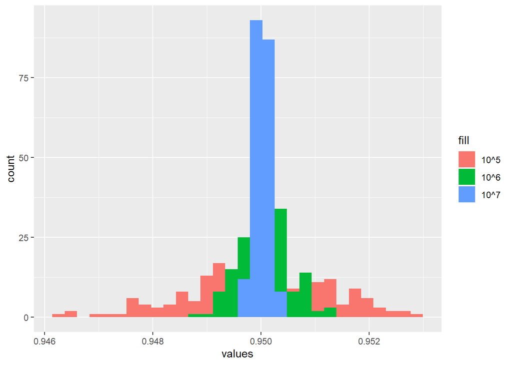

```r
library(ggplot2)
n <- c(10**5, 10**6, 10**7)
result <- list()
j <- 1
for(ni in n){
  approximationen <- c()
  for(i in 1:200){
    x <- runif(ni, -1.96, 1.96)
    z <- mean(2*1.96*dnorm(x)) # dnorm = Dichte der Standardnormalverteilung
    approximationen <- c(approximationen, z)
  }
  result[[j]] <- approximationen
  j <- j+1
}


ggplot() +
  geom_histogram(data=data.frame(values=result[[1]]), aes(x=values, fill="10^5"),) +
  geom_histogram(data=data.frame(values=result[[2]]), aes(x=values, fill="10^6")) +
  geom_histogram(data=data.frame(values=result[[3]]), aes(x=values, fill="10^7")) +
  labs()
```

Je höher n gewählt wird, desto präziser ist die Approximation des 0.975-Quantils.

### Fläche berechnen mit Hilfe der Monte-Carlo-Integration

[figure not shown]

```r
n <- 10^5
points <- c()

x <- runif(n, -7,7)
y <- runif(n, -4,4)
fläche <- ((x^2/49) + (y^2) / 9 - 1 <= 0) &(((abs(x) >= 4) & ((-3*sqrt(33))/7 <= y & y <= 0)) | (abs(x) >= 3 & y >= 0)) | (-3 <= y & y <= 0 & -4 <= x & x <= 4 &((( -3*sqrt(33)-7)*x^2)/112 + abs(x)/2 + sqrt(1-(abs(abs(x)-2)-1)^2) -y -3 <=0)) | (y >= 0 & 3/4 <= abs(x) & abs(x) <= 1 & -8*abs(x)-y+9>=0) |(1/2<=abs(x) & abs(x)<=3/4 & 3* abs(x) - y +3/4 >= 0 & y >= 0) | (abs(x) <= 1/2 & y >= 0 & 9/4 - y >= 0) |(1<= abs(x) & abs(x)<=3 & y >= 0 & -abs(x)/2 -3/7*sqrt(10)*sqrt(4-(abs(x) -1)^2) - y +(6*sqrt(10))/7 + 3/2 >= 0)
plot(x[fläche], y[fläche])
```

```r
b <- 7
a <- -7
d <- 4
c <- -4
A <- (b-a)*(d-c)*sum(fläche)
A
```

```
## [1] 5360992
```